```python
import networkx as nx
import matplotlib.pyplot as plt
import numpy as np
```

# Exercise 8 - a) E-Road Network

## Read the graph

```python
G= nx.read_edgelist("data/euroroad.txt", nodetype=int) # Read the network
Gcc=sorted(nx.connected_component_subgraphs(G), key = len, reverse=True)
G=Gcc[0]
G = nx.convert_node_labels_to_integers(G, first_label=0)
nodes = nx.number_of_nodes(G)
print('The E-Road Network has',nodes, 'nodes')
```

```
The E-Road Network has 1039 nodes
```

## Degree

```python
vk = dict(G.degree())
vk = list(vk.values())
vk = np.array(vk)
print('Degree', vk)
```

```
Degree [2 8 2 ... 2 2 1]
```

## Mean Degree

```python
md = np.mean(vk)
print('Mean degree: ', md)
```

```
Mean degree:  2.512030798845043
```

## Function for degree distribution

```python
def degree_distribution(G):
    vk = dict(G.degree())
    vk = list(vk.values())  # we get only the degree values
    vk = np.array(vk)
    maxk = np.max(vk)
    mink = np.min(vk)
    kvalues= range(0,maxk+1) # possible values of k
    Pk = np.zeros(maxk+1) # P(k)
    for k in vk:
        Pk[k] = Pk[k] + 1
    Pk = Pk/sum(Pk) # the sum of the elements of P(k) must to be equal to one
    return kvalues,Pk
```

## Function to plot histogram

```python
def plot_histogram(G):
    ks, Pk = degree_distribution(G)

    fig, ax = plt.subplots()
    plt.bar(ks, Pk, width=0.80, color='b')



    plt.title("Degree Histogram")
    plt.ylabel("P(k)")
    plt.xlabel("k")
    ax.set_xticks([d + 0.4 for d in ks])
    ax.set_xticklabels(ks)
    plt.show()
```

## E-Road histogram

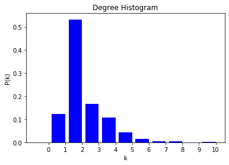

```python
plot_histogram(G)
```

# Exercise 8 - b) Facebook user-user friendships

## Read the graph

```python
G= nx.read_edgelist("data/out.ego-facebook", nodetype=int, comments='%') # Read the network
Gcc=sorted(nx.connected_component_subgraphs(G), key = len, reverse=True)
G=Gcc[0]
G = nx.convert_node_labels_to_integers(G, first_label=0)
nodes = nx.number_of_nodes(G)
print('The Facebook user-user friendships network has',nodes, 'nodes')
```

```
The Facebook user-user friendships network has 2888 nodes
```

## Degree

```python
vk = dict(G.degree())
vk = list(vk.values())
vk = np.array(vk)
print('Degree', vk)
```

```
Degree [287   1   1 ...   1   1   1]
```

## Mean Degree

```python
md = np.mean(vk)
print('Mean degree: ', md)
```

```
Mean degree:  2.064404432132964
```

## Facebook histogram

[figure not shown]

```python
plot_histogram(G)
```

### The histogram isn't being drawn as expected due to the fact of only a few nodes having a high degree and a very large number of nodes with low degree (mean degree is 2 and we have at least one node with degree 287). However this indicates probably a scale free network since the high degree nodes are clearly hubs.

# Exercise 8 - c) Collaboration of authors

## Read the graph

```python
G= nx.read_edgelist("data/astroPh.txt", nodetype=int, comments='%') # Read the network
Gcc=sorted(nx.connected_component_subgraphs(G), key = len, reverse=True)
G=Gcc[0]
G = nx.convert_node_labels_to_integers(G, first_label=0)
nodes = nx.number_of_nodes(G)
print('The collaboration of authors from arXiv’s Astrophysics network has',nodes, 'nodes')
```

```
The collaboration of authors from arXiv’s Astrophysics network has 17903 nodes
```

## Degree

```python
vk = dict(G.degree())
vk = list(vk.values())
vk = np.array(vk)
print('Degree', vk)
```

```
Degree [75 31 43 ...  1  1  3]
```

## Mean Degree

```python
md = np.mean(vk)
print('Mean degree: ', md)
```

```
Mean degree:  22.004356811707535
```

## Collaboration histogram

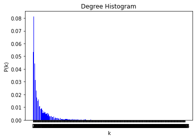

```python
plot_histogram(G)
```

### The collaboration network is scale free since P(k) ~ k^(-a) (2 < a < 3), which means there's a large probability of randomly choosing a low degree node and a small probability of randomly choosing a high degree node, which indicates the presence of hubs in the network.

# Exercise 8 - d) Hamsterster friendships

## Read the graph

```python
G= nx.read_edgelist("data/out.petster-friendships-hamster-uniq", nodetype=int, comments='%') # Read the network
Gcc=sorted(nx.connected_component_subgraphs(G), key = len, reverse=True)
G=Gcc[0]
G = nx.convert_node_labels_to_integers(G, first_label=0)
nodes = nx.number_of_nodes(G)
print('The Hamsterter friendships network has',nodes, 'nodes')
```

```
The Hamsterter friendships network has 1788 nodes
```

## Degree

```python
vk = dict(G.degree())
vk = list(vk.values())
vk = np.array(vk)
print('Degree', vk)
```

```
Degree [27 45  3 ...  1  8  3]
```

## Mean Degree

```python
md = np.mean(vk)
print('Mean degree: ', md)
```

```
Mean degree:  13.955257270693512
```

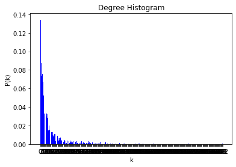

```python
plot_histogram(G)
```

### The Hamsterter friendships network is scale free since P(k) ~ k^(-a) (2 < a < 3), which means there's a large probability of randomly choosing a low degree node and a small probability of randomly choosing a high degree node, which indicates the presence of hubs in the network.